# STA 260 Final Project

## Total Case Rate and High Risk Case Rate vs % Population over 65 and % Rural Population

County case rate and county death rate in January 2021 appears to be negatively correlated with % county population over 65 and % county rural population. This relationship is much less apparent in months where COVID case rate is relatively low, such as in May 2020; it’s only clearly seen during peaks of COVID wave such as July 2020 and December 2020-January 2021. The negative trend might be because COVID-19 is more readily spread by young people and in crowded, urban areas.

No apparent relationship between county case/death rates and median household income for any month

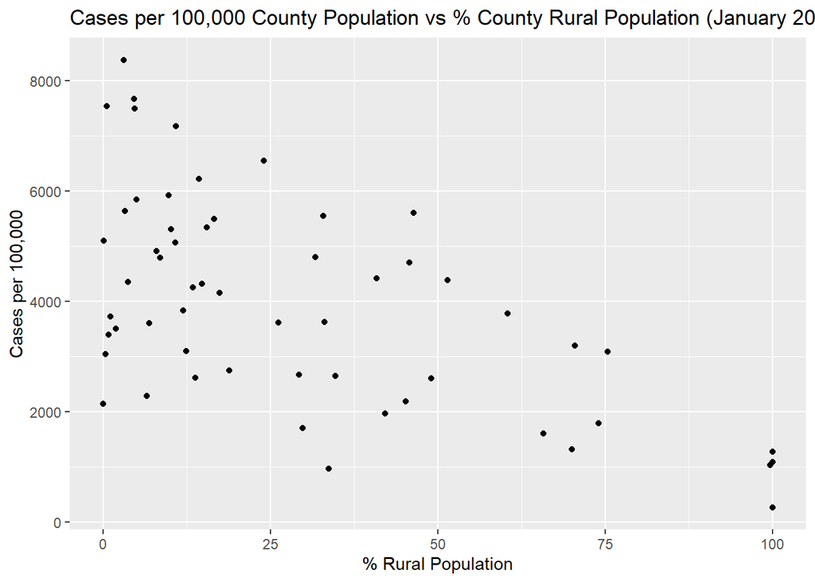

```r
ggplot(subset(cases_by_month, month=="2021-01-01"), aes(x=perc_rural, y=count/Population))+
  geom_point()+
  ggtitle("Cases per 100,000 County Population vs % County Rural Population (January 2021)") +
  xlab("% Rural Population")+
  ylab("Cases per 100,000")
```

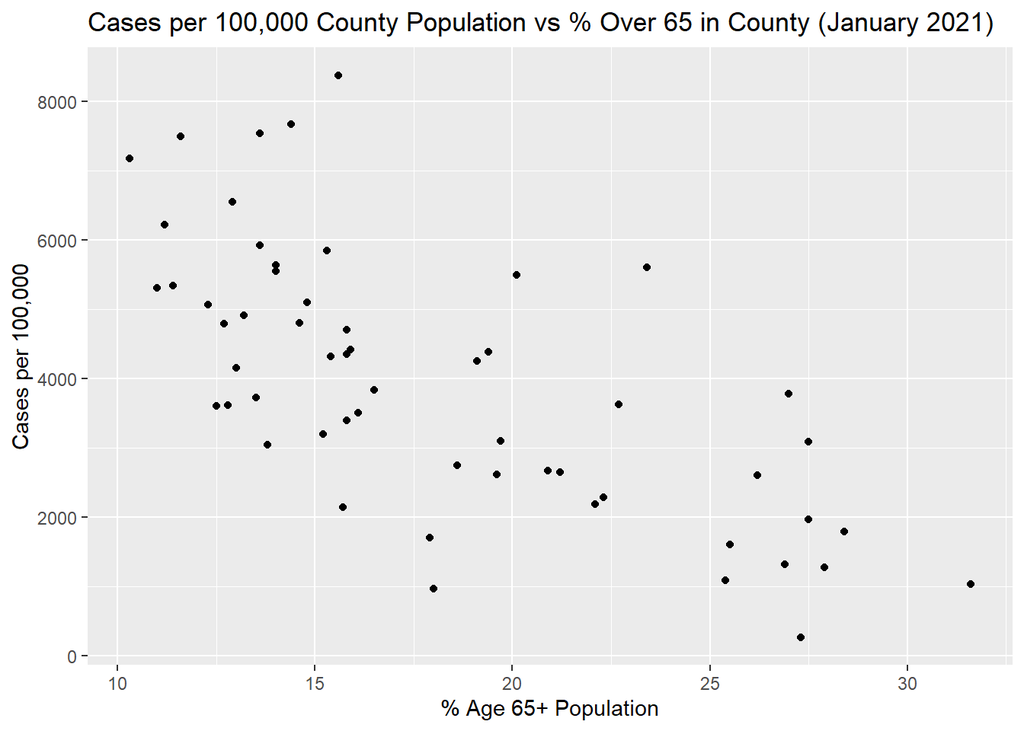

```r
ggplot(subset(cases_by_month, month=="2021-01-01"), aes(x=perc_over_65, y=count/Population))+
  geom_point()+
  ggtitle("Cases per 100,000 County Population vs % Over 65 in County (January 2021)") +
  xlab("% Age 65+ Population")+
  ylab("Cases per 100,000")
```

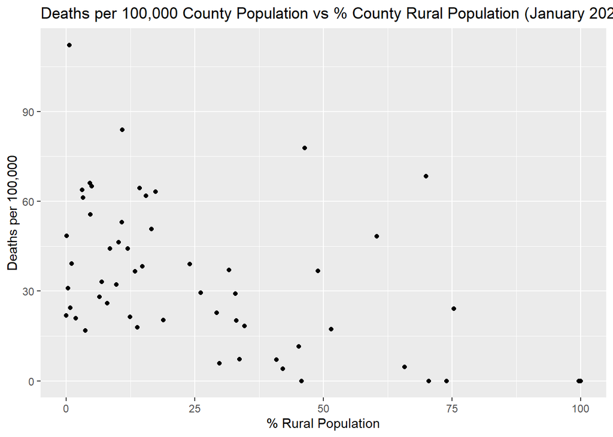

```r
ggplot(subset(cases_by_month, month=="2021-01-01"), aes(x=perc_rural, y=deaths/Population))+
  geom_point()+
  ggtitle("Deaths per 100,000 County Population vs % County Rural Population (January 2021)")+
  xlab("% Rural Population")+
  ylab("Deaths per 100,000")
```

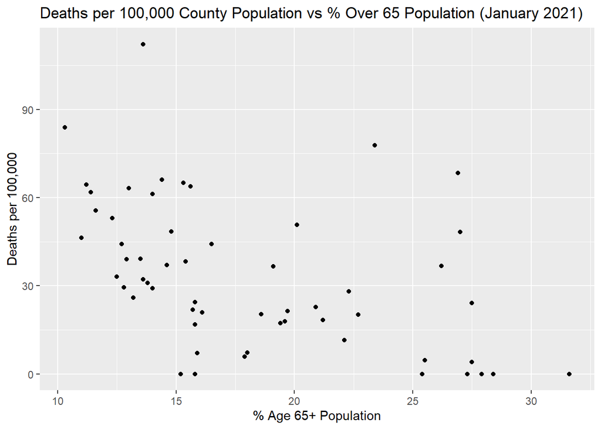

```r
ggplot(subset(cases_by_month, month=="2021-01-01"), aes(x=perc_over_65, y=deaths/Population))+
  geom_point()+
  ggtitle("Deaths per 100,000 County Population vs % Over 65 Population (January 2021)")+
  xlab("% Age 65+ Population")+
  ylab("Deaths per 100,000")
```

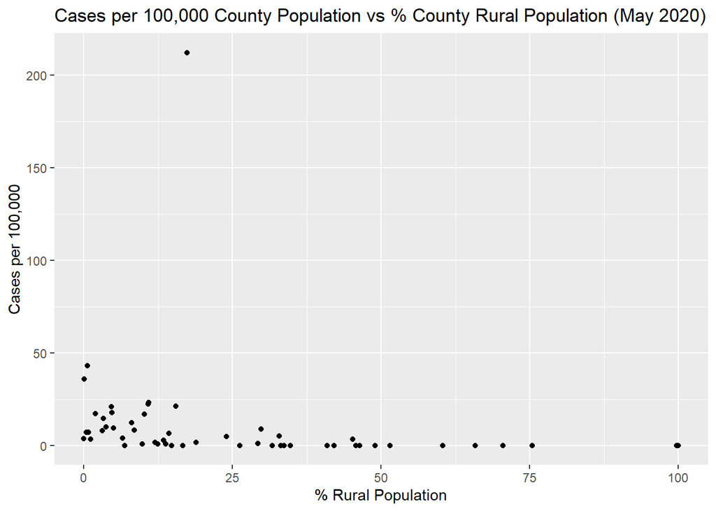

```r
# death vs percent rural plots for May 2020 (not during a COVID peak)

ggplot(subset(cases_by_month, month=="2020-05-01"), aes(x=perc_rural, y=deaths/Population))+
  geom_point()+
  ggtitle("Cases per 100,000 County Population vs % County Rural Population (May 2020)") +
  xlab("% Rural Population")+
  ylab("Cases per 100,000")
```

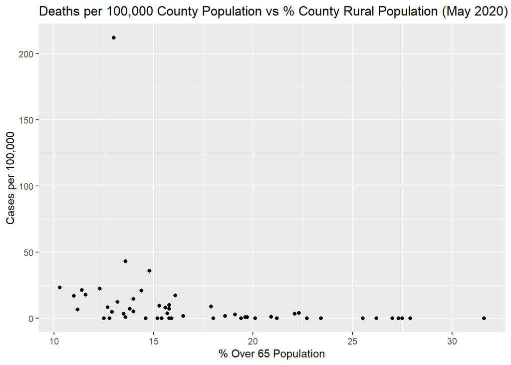

```r
ggplot(subset(cases_by_month, month=="2020-05-01"), aes(x=perc_over_65, y=deaths/Population))+
  geom_point()+
  ggtitle("Deaths per 100,000 County Population vs % County Rural Population (May 2020)") +
  xlab("% Over 65 Population")+
  ylab("Cases per 100,000")
```

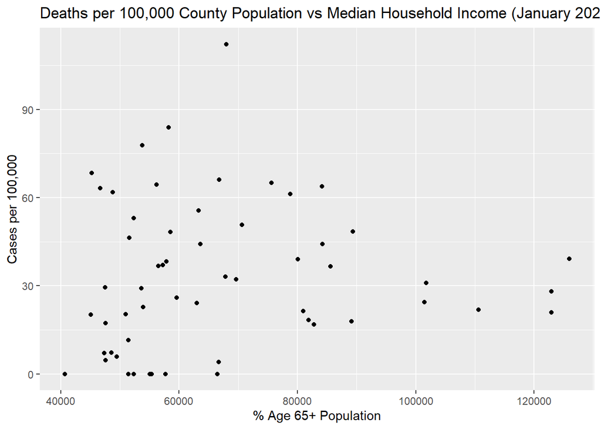

```r
#income vs deaths (no apparent relationship)

ggplot(subset(cases_by_month, month=="2021-01-01"), aes(x=median_household_income, y=deaths/Population))+
  geom_point()+
  ggtitle("Deaths per 100,000 County Population vs Median Household Income (January 2021)")+
  xlab("% Age 65+ Population")+
  ylab("Cases per 100,000")
```

## Heatmaps of Cases/Deaths/Hospitalizations/ICU by Age and Month

Total case counts for a given age group and county were divided by population of the county. Most of the cases are among younger people, 20-39 year olds in particular, but most of the deaths are among older people

```r
cases_by_age = ca_covid %>%
  group_by(res_county, age_group) %>%
  summarise(count=n(), deaths=sum(death_yn=="Yes", na.rm=TRUE),
            hosp=sum(hosp_yn=="Yes", na.rm=TRUE),
            icu=sum(icu_yn=="Yes", na.rm=TRUE),
            high_risk=(sum(high_risk=="Yes", na.rm=TRUE)))
```

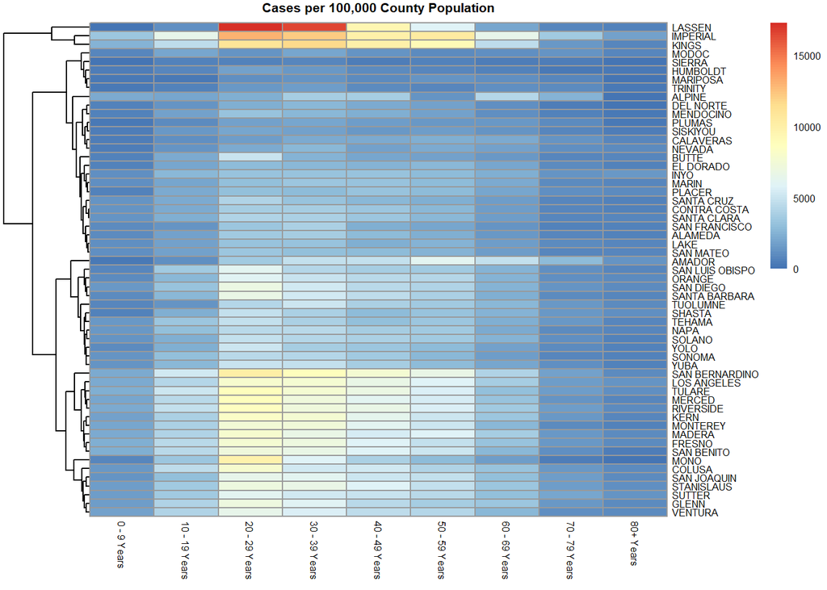

```r
cases_by_age = left_join(cases_by_age, ca_pop, by = c("res_county" = "county"))

pheatmap(xtabs(count/Population~res_county+age_group, cases_by_age), cluster_cols=FALSE, fontsize =6, main="Cases per 100,000 County Population")
```

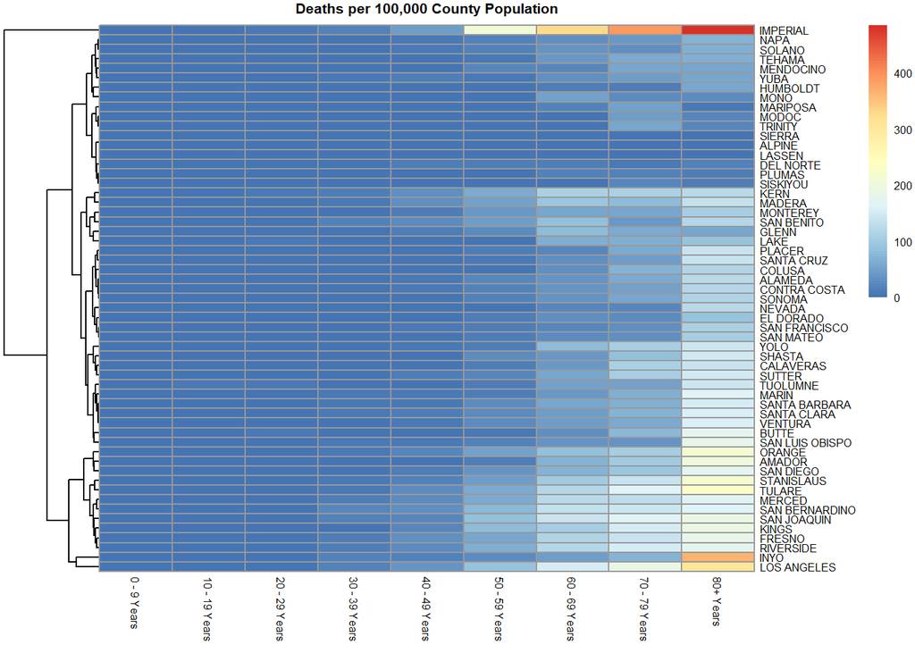

```r
pheatmap(xtabs(deaths/Population~res_county+age_group, cases_by_age), cluster_cols=FALSE, fontsize =6, main="Deaths per 100,000 County Population")
```

Death/hospitalization/ICU counts were divided by the total number of cases for that age group in that county to get the death/hosp/ICU-to-case ratio. Among COVID cases, older patients (70+) are much more likely to die, be hospitalized, or go to the ICU across almost all counties.

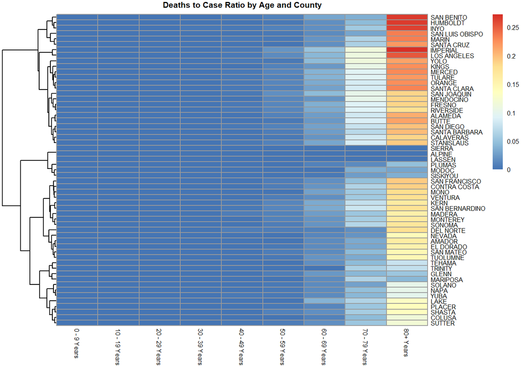

```r
pheatmap(xtabs(deaths/count~res_county+age_group, cases_by_age), cluster_cols=FALSE, fontsize =6, main="Deaths to Case Ratio by Age and County")
```

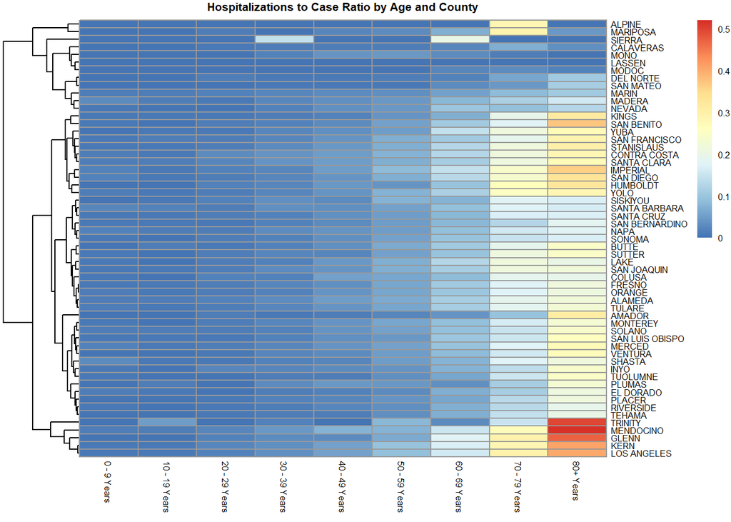

```r
pheatmap(xtabs(hosp/count~res_county+age_group, cases_by_age), cluster_cols=FALSE, fontsize =6, main="Hospitalizations to Case Ratio by Age and County")
```

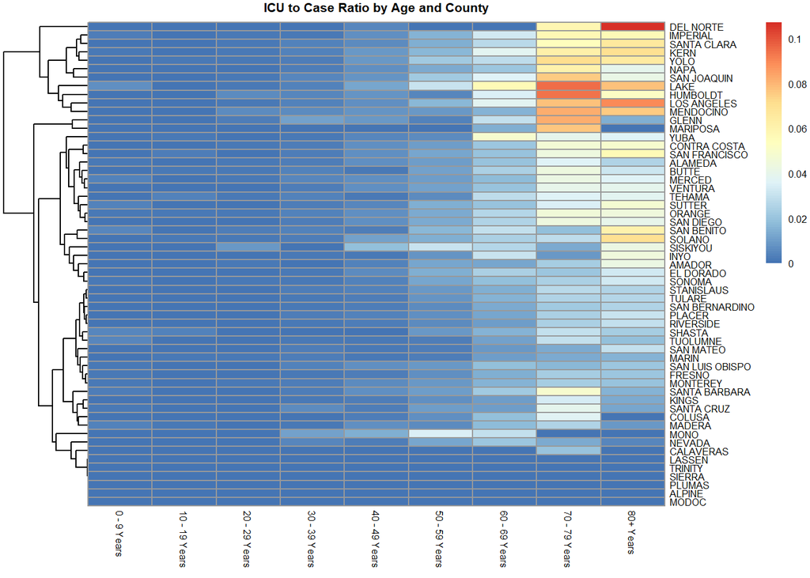

```r
pheatmap(xtabs(icu/count~res_county+age_group, cases_by_age), cluster_cols=FALSE, fontsize =6, main="ICU to Case Ratio by Age and County")
```

#Race-Specific Rates by County

Counts of cases of a particular race in a county were divided by the population of that race in that county to get the race-specific rates. Note that Hispanic population was left out because the COVID-19 dataset has no patients marked Hispanic (might be data entry error?). Multiple/Other was also left out due to a lack of county population data for this race/ethnicity.

```r
county_race = read_csv("county race.csv")
county_race$county = toupper(county_race$county)

melt_race = melt(county_race)
names(melt_race)[3] = "racepop"
cases_by_race = ca_covid %>%
  group_by(res_county, race_ethnicity_combined) %>%
  summarise(count=n(), deaths=sum(death_yn=="Yes", na.rm=TRUE),
            hosp=sum(hosp_yn=="Yes", na.rm=TRUE),
            icu=sum(icu_yn=="Yes", na.rm=TRUE),
            high_risk=(sum(high_risk=="Yes", na.rm=TRUE)))
```

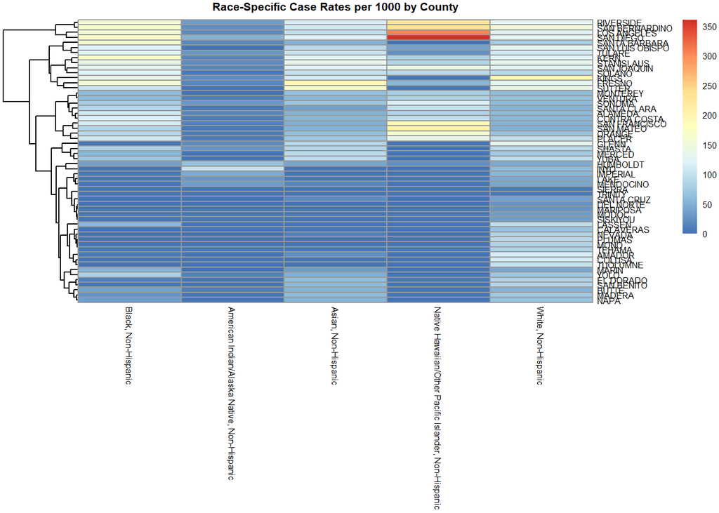

```r
cases_by_race = left_join(melt_race, cases_by_race, by = c("county" = "res_county","variable" = "race_ethnicity_combined" ))
cases_by_race$variable = droplevels(cases_by_race$variable)
cases_by_race$region = ca_pop$region



pheatmap(xtabs(count/racepop*1000~county+variable, cases_by_race), cluster_cols=FALSE, fontsize =6, main="Race-Specific Case Rates per 1000 by County")
```

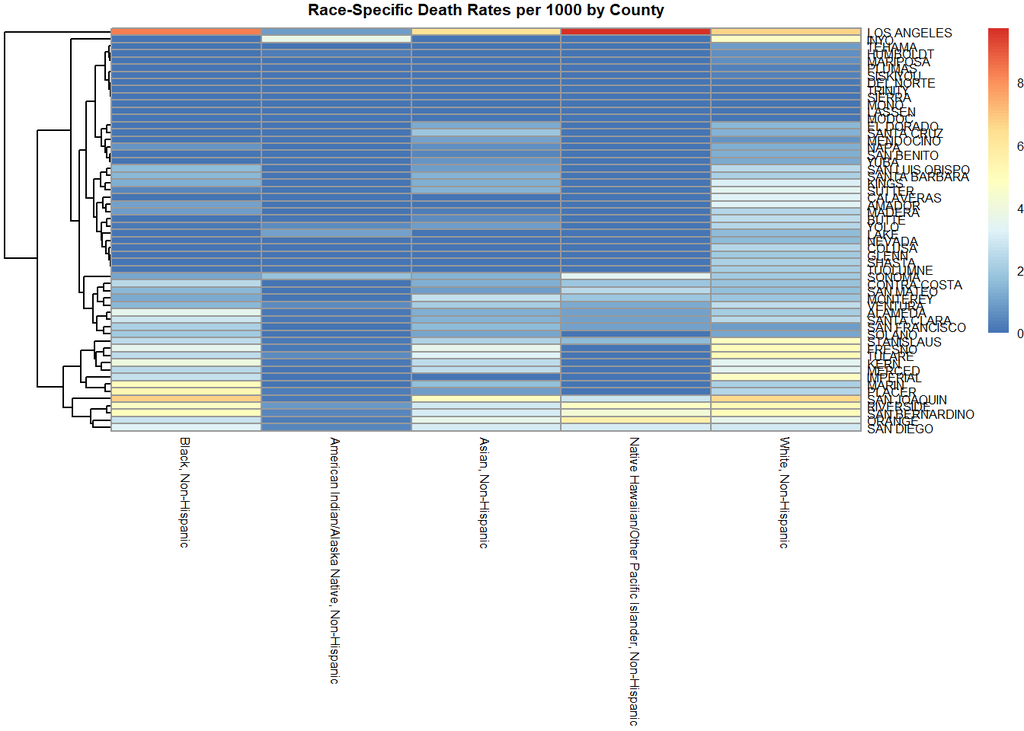

```r
pheatmap(xtabs(deaths/racepop*1000~county+variable, cases_by_race), cluster_cols=FALSE, fontsize =6, main="Race-Specific Death Rates per 1000 by County")
```

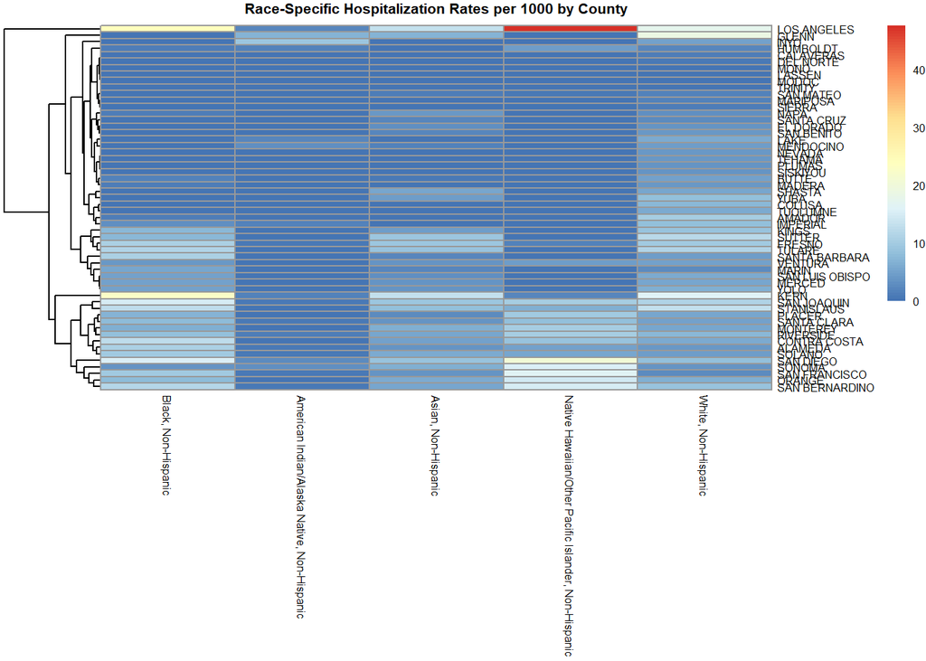

```r
pheatmap(xtabs(hosp/racepop*1000~county+variable, cases_by_race), cluster_cols=FALSE, fontsize =6, main="Race-Specific Hospitalization Rates per 1000 by County")
```

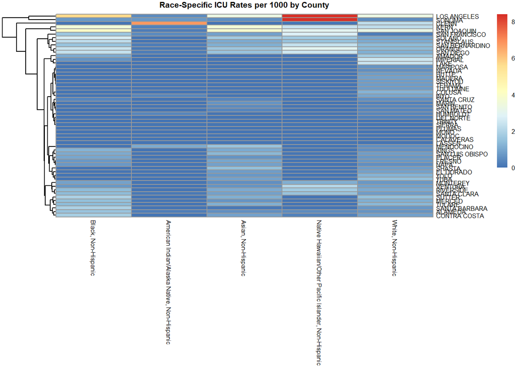

```r
pheatmap(xtabs(icu/racepop*1000~county+variable, cases_by_race), cluster_cols=FALSE, fontsize =6, main="Race-Specific ICU Rates per 1000 by County")
```